# Evaluation of KIR-receptor impact on graft function disruption after allogeneic hematopoietic stem cell transplantation

13.08.2023

Слайды на английском, а комментарии к коду на русском. Just deal with it :)

# Методы анализа

Расчёт проведён в R studio 2023.06.1 Build 524 с помощью языка R версии 4.3.0. Для описания категориальных переменных были рассчитаны абсолютные (n) и относительные (%) частоты. Для количественных переменных рассчитывали медианы, размах минимум-максимум, интерквартильные диапазоны. Сравнение категориальных переменных в двух группах проводили с помощью критерия Хи-квадрат либо точного критерия Фишера, сравнение количественных переменных - с помощью критерия Вилкоксона-Манна-Уитни с помощью пакета gtsummary 1.7.1. Корреляционный анализ проводили с помощью коэффициента корреляции Пирсона. Для предикции развития исхода проводили построение моделей логистической регрессии. Анализ времени до наступления исходов проводили с помощью построения кривых Каплана-Майера и построения моделей логистической регрессии Кокса. Уровень ошибки первого рода был принят равным 0.05, нулевые гипотезы отвергали при p < 0.05.

Данное исследование являлось поисковым. Нами была поставлена цель проверить возможность использования данных о наличии KIR-рецепторов для прогнозирования несостоятельности графта. В связи с этим и с малым объёмом выборки (n = 69) набор данных не разделяли на train и test. Полученные результаты нуждаются в дополнительной внутренней и внешней валидации.

# Задачи проекта

Task 1: Identify KIR landscape in donor-recipient pairs and their combination.

Task 2: Find associations between types of transplantation and KIR landscape.

Task 3: Using biostatistics and machine learning methods identify the relationship between KIR in donor-recipient pairs and transplant outcomes.

Task 4: Find associations of KIR clusters and the function of the transplant.

# Клиническая характеристика группы, включённой в анализ

Табличка для слайда “Материал и методы”

| **Characteristic** | **N = 69**<sup>1</sup> |
| --- | --- |
| Age | 37 (31, 43); 18 to 63 |
| Sex |  |
| female | 37 (54%) |
| male | 32 (46%) |
| Diagnosis |  |
| ALL | 25 (36%) |
| AML | 44 (64%) |
| BMT number |  |
| 1 | 65 (94%) |
| 2 | 2 (2.9%) |
| 3 | 2 (2.9%) |
| Transplantation |  |
| BM | 7 (10%) |
| PBSC | 62 (90%) |
| Failure |  |
| Primary | 23 (33%) |
| Secondary | 13 (19%) |
| None | 33 (48%) |

<sup>1</sup> Median (IQR); Range; n (%)

## Данные по KIR-рецепторам в анализируемой группе

В данном и трёх последующих разделах проведён анализ данных по задачам 1 и 2. Проанализирован “лашдшафт” встречаемости рецепторов, а также проанализированы ассоциации между встречаемостью рецепторов и видом родственной трансплантации.

| **Characteristic** | **N = 69**<sup>1</sup> |
| --- | --- |
| 2DL1 | 68 (99%) |
| 2DL2 | 38 (55%) |
| 2DL3 | 57 (83%) |
| 2DL5 | 39 (57%) |
| 2DS1 | 30 (43%) |
| 2DS2 | 33 (48%) |
| 2DS3 | 26 (38%) |
| 2DS4d | 57 (83%) |
| 2DS4f | 13 (19%) |
| 2DS5 | 21 (30%) |
| 3DS1 | 27 (39%) |
| Best VS Better/Neutral | 12 (17%) |
| Best/Better VS Neutral | 26 (38%) |
| Mismatching in the GvH Direction, HLA-A03/11 | 9 (13%) |
| Mismatching in the HvG Direction, HLA-A03/11 | 7 (10%) |
| HLA-Bw4. patient | 53 (77%) |
| HLA-Bw4, donor | 55 (80%) |
| HLA-C1/C1, patient | 21 (30%) |
| HLA-C1/C1, donor | 20 (29%) |
| HLA-C1/С2. patient | 30 (43%) |
| HLA-C1/С2, donor | 33 (48%) |
| HLA-C2/C2. patient | 18 (26%) |
| HLA-C2/C2, donor | 16 (23%) |
| KIR-genotype A/A vs B/X | 23 (33%) |
| KIR-genotype B/B vs A/X | 16 (23%) |
| Mismatching in the GvH Direction, HLA-B | 9 (13%) |
| Mismatching in the GvH Direction, HLA-C | 14 (20%) |
| Mismatching in the HvG Direction, HLA-B | 8 (12%) |
| Mismatching in the HvG Direction, HLA-C | 11 (16%) |
| HLA-А3 & А11, donor | 23 (33%) |
| KIR count | 10.00 (7.00, 12.00); 7.00 to 15.00 |
| KIR active | 3.00 (1.00, 4.00); 1.00 to 8.00 |
| KIR ingibited | 7.00 (6.00, 7.00); 5.00 to 9.00 |

<sup>1</sup> n (%); Median (IQR); Range

## КИРы избранные, у донора

| **Characteristic** | **N = 69**<sup>1</sup> |
| --- | --- |
| 2DL1 | 68 (99%) |
| 2DL2 | 38 (55%) |
| 2DL3 | 57 (83%) |
| 2DL5 | 39 (57%) |
| 2DS1 | 30 (43%) |
| 2DS2 | 33 (48%) |
| 2DS3 | 26 (38%) |
| 2DS4d | 57 (83%) |
| 2DS4f | 13 (19%) |
| 2DS5 | 21 (30%) |

<sup>1</sup> n (%)

## Анализ ассоциации между KIR

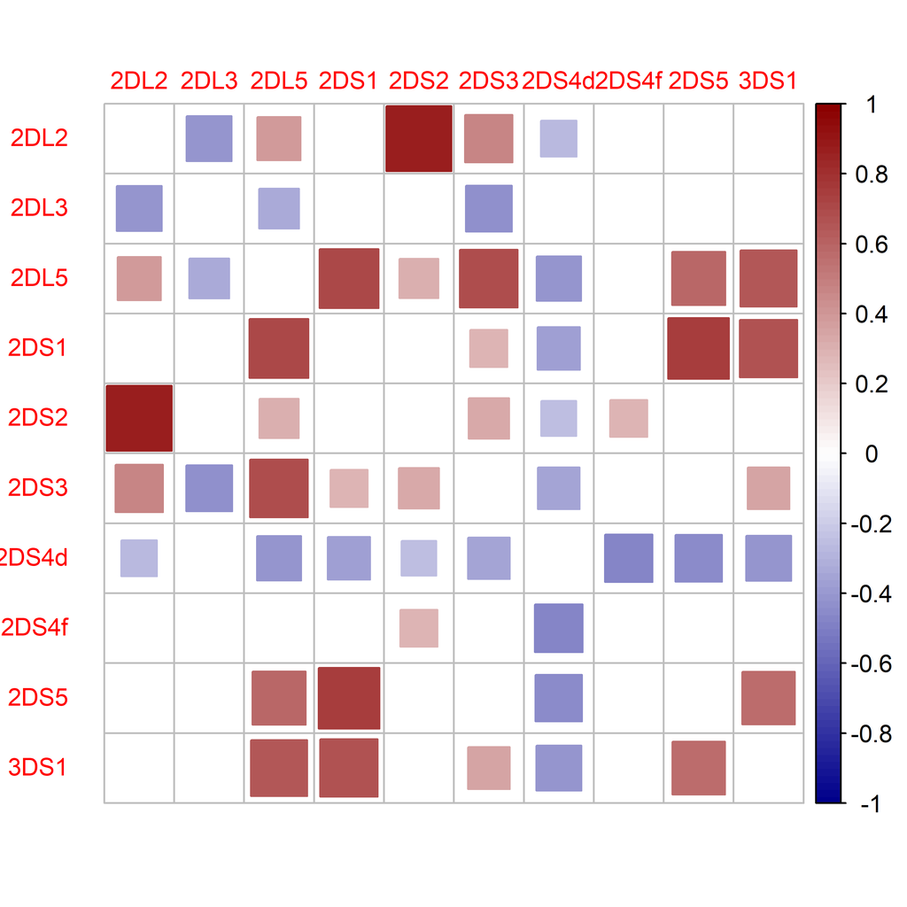

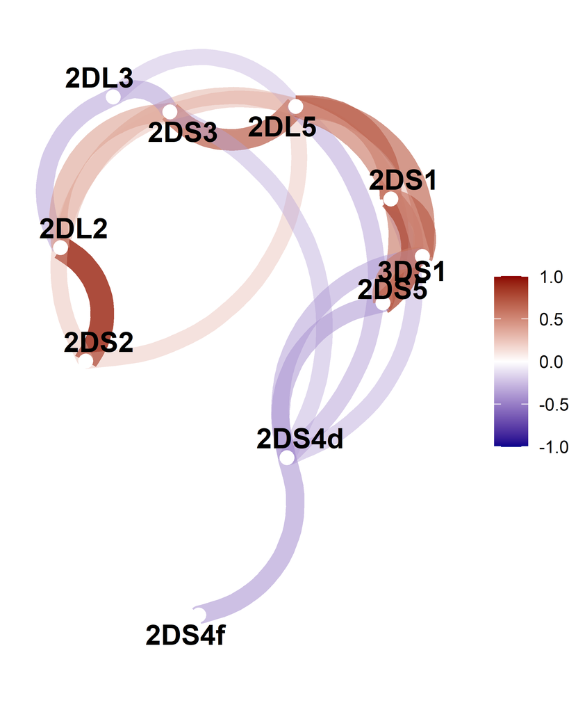

## Анализ связи с видом трансплантации

| **Characteristic** | **Transplantation type** **mismatch unrelated donor**, N = 21<sup>1</sup> | **Transplantation type** **mismatch related donor**, N = 45<sup>1</sup> | **p-value**<sup>2</sup> |  |
| --- | --- | --- | --- | --- |
| Mismatching in the GvH Direction, HLA-A03/11 | 2 (9.5%) | 7 (16%) |  | 0.7 |
| Mismatching in the HvG Direction, HLA-A03/11 | 3 (14%) | 4 (8.9%) | 0.7 |  |
| Mismatching in the GvH Direction, HLA-B | 0 (0%) | 9 (20%) | 0.048 |  |
| Mismatching in the GvH Direction, HLA-C | 1 (4.8%) | 13 (29%) | 0.027 |  |
| Mismatching in the HvG Direction, HLA-B | 2 (9.5%) | 6 (13%) | >0.9 |  |
| Mismatching in the HvG Direction, HLA-C | 1 (4.8%) | 10 (22%) | 0.2 |  |

<sup>1</sup> n (%)  
<sup>2</sup> Fisher’s exact test

# Анализ по гипофункции трансплантата

## Демография + Анамнез

| **Characteristic** | **Hypofunction** **0**, N = 33<sup>1</sup> | **Hypofunction** **1**, N = 36<sup>1</sup> | **p-value**<sup>2</sup> |  |
| --- | --- | --- | --- | --- |
| Age | 33 (30, 37); 18 to 56 | 39 (36, 48); 20 to 63 |  | 0.006 |
| Sex |  |  | 0.3 |  |
| female | 20 (61%) | 17 (47%) |  |  |
| male | 13 (39%) | 19 (53%) |  |  |
| Diagnosis |  |  | 0.3 |  |
| ALL | 14 (42%) | 11 (31%) |  |  |
| AML | 19 (58%) | 25 (69%) |  |  |
| BMT number |  |  | 0.5 |  |
| 1 | 30 (91%) | 35 (97%) |  |  |
| 2 | 2 (6.1%) | 0 (0%) |  |  |
| 3 | 1 (3.0%) | 1 (2.8%) |  |  |
| Transplantation |  |  | 0.012 |  |
| BM | 0 (0%) | 7 (19%) |  |  |
| PBSC | 33 (100%) | 29 (81%) |  |  |
| Failure |  |  | <0.001 |  |
| Primary | 0 (0%) | 23 (64%) |  |  |
| Secondary | 0 (0%) | 13 (36%) |  |  |
| None | 33 (100%) | 0 (0%) |  |  |

<sup>1</sup> Median (IQR); Range; n (%)  
<sup>2</sup> Wilcoxon rank sum test; Pearson’s Chi-squared test; Fisher’s exact test

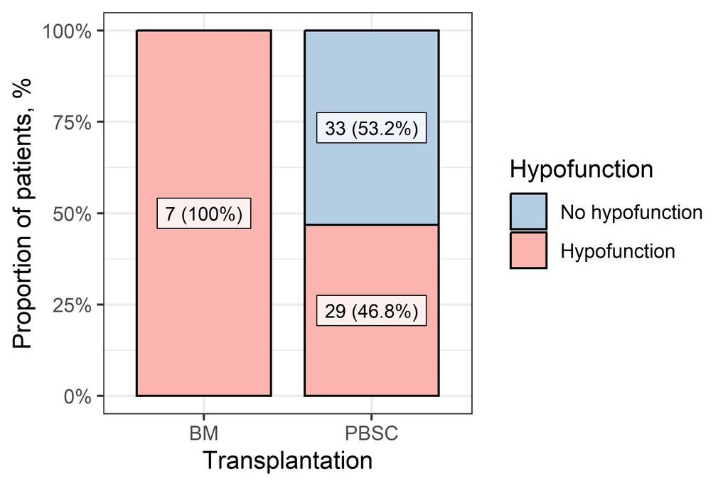

## КИРы все

| **Characteristic** | **Hypofunction** **0**, N = 33<sup>1</sup> | **Hypofunction** **1**, N = 36<sup>1</sup> | **p-value**<sup>2</sup> |  |
| --- | --- | --- | --- | --- |
| 2DL1 |  |  |  | 0.5 |
| yes | 32 (47%) | 36 (53%) |  |  |
| no | 1 (100%) | 0 (0%) |  |  |
| 2DL2 |  |  | 0.4 |  |
| yes | 20 (53%) | 18 (47%) |  |  |
| no | 13 (42%) | 18 (58%) |  |  |
| 2DL3 |  |  | 0.3 |  |
| yes | 29 (51%) | 28 (49%) |  |  |
| no | 4 (33%) | 8 (67%) |  |  |
| 2DL5 |  |  | 0.9 |  |
| yes | 19 (49%) | 20 (51%) |  |  |
| no | 14 (47%) | 16 (53%) |  |  |
| 2DS1 |  |  | 0.8 |  |
| yes | 15 (50%) | 15 (50%) |  |  |
| no | 18 (46%) | 21 (54%) |  |  |
| 2DS2 |  |  | 0.3 |  |
| yes | 18 (55%) | 15 (45%) |  |  |
| no | 15 (42%) | 21 (58%) |  |  |
| 2DS3 |  |  | 0.8 |  |
| yes | 13 (50%) | 13 (50%) |  |  |
| no | 20 (47%) | 23 (53%) |  |  |
| 2DS4d |  |  | 0.038 |  |
| yes | 24 (42%) | 33 (58%) |  |  |
| no | 9 (75%) | 3 (25%) |  |  |
| 2DS4f |  |  | 0.003 |  |
| yes | 11 (85%) | 2 (15%) |  |  |
| no | 22 (39%) | 34 (61%) |  |  |
| 2DS5 |  |  | 0.6 |  |
| yes | 11 (52%) | 10 (48%) |  |  |
| no | 22 (46%) | 26 (54%) |  |  |

[output cut: 63 more lines]

<sup>1</sup> n (%); Median (IQR)  
<sup>2</sup> Fisher’s exact test; Pearson’s Chi-squared test; Wilcoxon rank sum test

## Графики

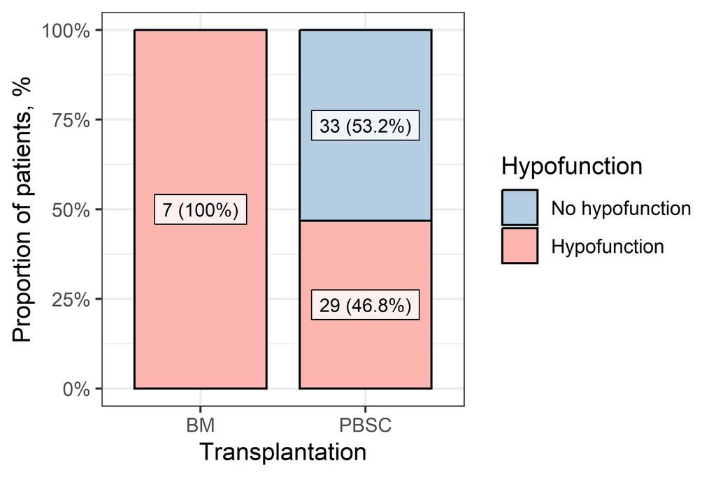

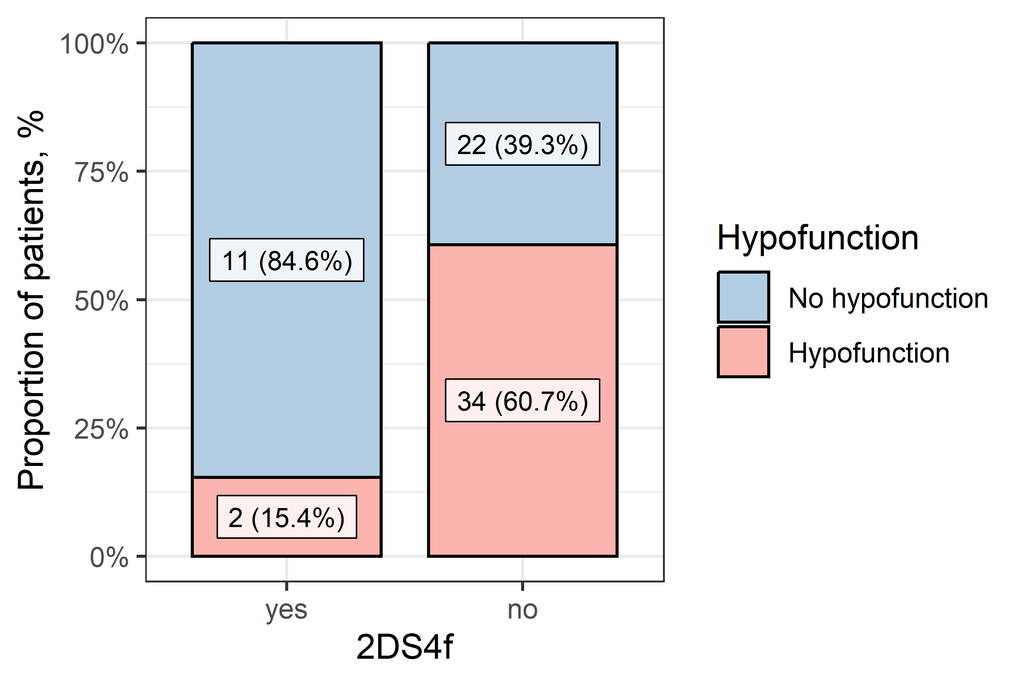

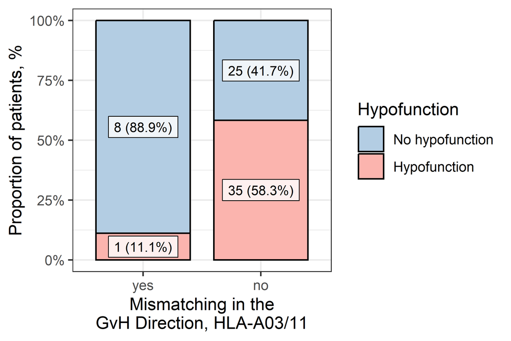

## Попытка создания критерия оценки для наступления недостаточности

В данном разделе проводился анализ по задачам 3 и 4: были проанализированы факторы, которые влияли на развитие гипофункции трансплантата, разработана модель для прогнозирования гипофункции трансплантата.

### Однофакторная логистическая регрессия

#### Анамнез + демография

| **Characteristic** | **N** | **OR**<sup>1</sup> | **95% CI**<sup>1</sup> | **p-value** |
| --- | --- | --- | --- | --- |
| Age | 69 | 1.07 | 1.01, 1.13 | 0.021 |
| Sex | 69 |  |  |  |
| female |  | — | — |  |
| male |  | 1.72 | 0.66, 4.55 | 0.3 |
| Diagnosis | 69 |  |  |  |
| ALL |  | — | — |  |
| AML |  | 1.67 | 0.63, 4.58 | 0.3 |
| BMT number | 69 | 0.61 | 0.11, 2.27 | 0.5 |
| Transplantation | 69 |  |  |  |
| BM |  | — | — |  |
| PBSC |  | 0.00 |  | >0.9 |

<sup>1</sup> OR = Odds Ratio, CI = Confidence Interval

#### KIR

| **Characteristic** | **N** | **OR**<sup>1</sup> | **95% CI**<sup>1</sup> | **p-value** |
| --- | --- | --- | --- | --- |
| 2DL1 | 69 | 6,477,540 | 0.00, NA | >0.9 |
| 2DL2 | 69 | 0.65 | 0.25, 1.68 | 0.4 |
| 2DL3 | 69 | 0.48 | 0.12, 1.72 | 0.3 |
| 2DL5 | 69 | 0.92 | 0.35, 2.39 | 0.9 |
| 2DS1 | 69 | 0.86 | 0.33, 2.23 | 0.8 |
| 2DS2 | 69 | 0.60 | 0.23, 1.54 | 0.3 |
| 2DS3 | 69 | 0.87 | 0.33, 2.31 | 0.8 |
| 2DS4d | 69 | 4.13 | 1.10, 20.1 | 0.049 |
| 2DS4f | 69 | 0.12 | 0.02, 0.49 | 0.009 |
| 2DS5 | 69 | 0.77 | 0.27, 2.16 | 0.6 |
| 3DS1 | 69 | 0.47 | 0.17, 1.24 | 0.13 |
| Best VS Better/Neutral | 69 | 2.07 | 0.58, 8.48 | 0.3 |
| Best/Better VS Neutral | 69 | 0.68 | 0.25, 1.80 | 0.4 |
| Mismatching in the GvH Direction, HLA-A03/11 | 69 | 0.09 | 0.00, 0.53 | 0.027 |
| Mismatching in the HvG Direction, HLA-A03/11 | 69 | 1.25 | 0.26, 6.79 | 0.8 |
| HLA-Bw4. patient | 69 | 1.12 | 0.36, 3.48 | 0.8 |
| HLA-Bw4, donor | 69 | 0.36 | 0.09, 1.21 | 0.11 |
| HLA-C1/C1, patient | 69 | 1.01 | 0.36, 2.86 | >0.9 |
| HLA-C1/C1, donor | 69 | 1.17 | 0.41, 3.40 | 0.8 |
| HLA-C1/С2. patient | 69 | 0.86 | 0.33, 2.23 | 0.8 |
| HLA-C1/С2, donor | 69 | 0.95 | 0.37, 2.46 | >0.9 |
| HLA-C2/C2. patient | 69 | 1.20 | 0.41, 3.62 | 0.7 |
| HLA-C2/C2, donor | 69 | 0.89 | 0.29, 2.77 | 0.8 |
| KIR-genotype A/A vs B/X | 69 | 1.30 | 0.48, 3.62 | 0.6 |
| KIR-genotype B/B vs A/X | 69 | 1.73 | 0.56, 5.73 | 0.3 |
| Mismatching in the GvH Direction, HLA-B | 69 | 0.22 | 0.03, 0.99 | 0.071 |
| Mismatching in the GvH Direction, HLA-C | 69 | 0.63 | 0.18, 2.03 | 0.4 |
| Mismatching in the HvG Direction, HLA-B | 69 | 0.51 | 0.10, 2.26 | 0.4 |
| Mismatching in the HvG Direction, HLA-C | 69 | 0.46 | 0.11, 1.71 | 0.3 |
| HLA-А3 & А11, donor | 69 | 0.59 | 0.21, 1.62 | 0.3 |
| KIR count | 69 | 0.95 | 0.77, 1.16 | 0.6 |
| KIR active | 69 | 0.90 | 0.67, 1.18 | 0.4 |
| KIR ingibited | 69 | 0.97 | 0.56, 1.68 | >0.9 |
| hypo_time | 69 | 0.45 | 0.25, 0.67 | <0.001 |

<sup>1</sup> OR = Odds Ratio, CI = Confidence Interval

## Модель из нескольких факторов

### Проверка модели

Смотрим, не хуже ли работает модель, чем классификаторы по-отдельности

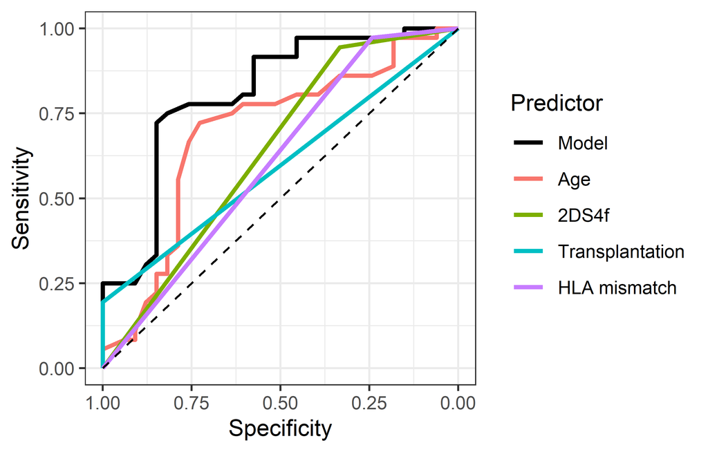

```
##
## Call:
## roc.data.frame(data = ., response = hypo_01, predictor = Predicted_hypo,     ci = T)
##
## Data: Predicted_hypo in 33 controls (hypo_01 0) < 36 cases (hypo_01 1).
## Area under the curve: 0.8093
## 95% CI: 0.7038-0.9149 (DeLong)
```

```
##   threshold specificity sensitivity
## 1 0.5831363   0.8484848   0.7222222
```

```
##               hypo_01
## Predicted_hypo  1  0
##              1 26  5
##              0 10 28
```

```
##           Outcome +    Outcome -      Total
## Test +           26            5         31
## Test -           10           28         38
## Total            36           33         69
##
## Point estimates and 95% CIs:
## --------------------------------------------------------------
## Apparent prevalence *                  0.449 (0.329, 0.574)
## True prevalence *                      0.522 (0.398, 0.644)
## Sensitivity *                          0.722 (0.548, 0.858)
## Specificity *                          0.848 (0.681, 0.949)
## Positive predictive value *            0.839 (0.663, 0.945)
## Negative predictive value *            0.737 (0.569, 0.866)
## Positive likelihood ratio              4.767 (2.073, 10.958)
## Negative likelihood ratio              0.327 (0.190, 0.565)
## False T+ proportion for true D- *      0.152 (0.051, 0.319)
## False T- proportion for true D+ *      0.278 (0.142, 0.452)
## False T+ proportion for T+ *           0.161 (0.055, 0.337)
## False T- proportion for T- *           0.263 (0.134, 0.431)
## Correctly classified proportion *      0.783 (0.667, 0.873)
## --------------------------------------------------------------
## * Exact CIs
```

## Дерево решений

Этот анализ был пробным и не фигурирует в финальном отчёте

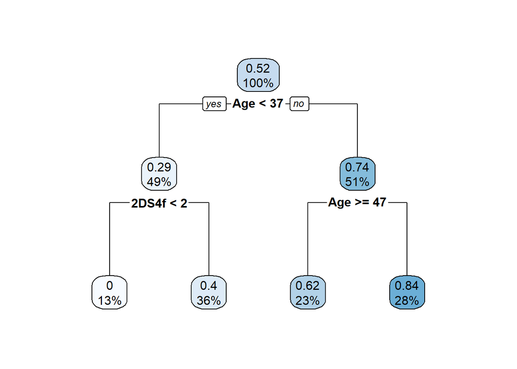

[output not shown]

## Анализ времени до наступления недостаточности

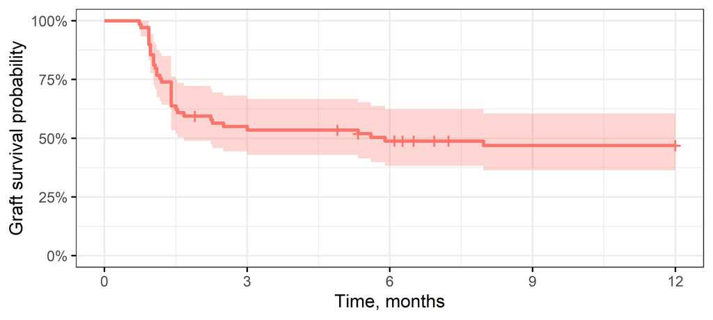

### Однофакторный анализ времени до наступления события

#### Анамнез + демография

| **Characteristic** | **N** | **HR**<sup>1</sup> | **95% CI**<sup>1</sup> | **p-value** |
| --- | --- | --- | --- | --- |
| Age | 69 | 1.04 | 1.01, 1.07 | 0.020 |
| Sex | 69 |  |  |  |
| female |  | — | — |  |
| male |  | 1.48 | 0.77, 2.85 | 0.2 |
| Diagnosis | 69 |  |  |  |
| ALL |  | — | — |  |
| AML |  | 1.26 | 0.62, 2.56 | 0.5 |
| BMT number | 69 | 0.74 | 0.23, 2.40 | 0.6 |
| Transplantation | 69 |  |  |  |
| BM |  | — | — |  |
| PBSC |  | 0.26 | 0.11, 0.61 | 0.002 |

<sup>1</sup> HR = Hazard Ratio, CI = Confidence Interval

#### KIR

| **Characteristic** | **N** | **HR**<sup>1</sup> | **95% CI**<sup>1</sup> | **p-value** |
| --- | --- | --- | --- | --- |
| 2DL1 | 69 | 25,030,201 | 0.00, Inf | >0.9 |
| 2DL2 | 69 | 0.68 | 0.36, 1.32 | 0.3 |
| 2DL3 | 69 | 0.68 | 0.31, 1.49 | 0.3 |
| 2DL5 | 69 | 0.90 | 0.46, 1.73 | 0.7 |
| 2DS1 | 69 | 0.85 | 0.44, 1.65 | 0.6 |
| 2DS2 | 69 | 0.60 | 0.31, 1.17 | 0.14 |
| 2DS3 | 69 | 0.91 | 0.46, 1.80 | 0.8 |
| 2DS4d | 69 | 2.92 | 0.89, 9.51 | 0.076 |
| 2DS4f | 69 | 0.18 | 0.04, 0.76 | 0.019 |
| 2DS5 | 69 | 0.77 | 0.37, 1.59 | 0.5 |
| 3DS1 | 69 | 0.62 | 0.30, 1.25 | 0.2 |
| Best VS Better/Neutral | 69 | 1.48 | 0.67, 3.24 | 0.3 |
| Best/Better VS Neutral | 69 | 0.72 | 0.36, 1.43 | 0.3 |
| Mismatching in the GvH Direction, HLA-A03/11 | 69 | 0.14 | 0.02, 0.99 | 0.049 |
| Mismatching in the HvG Direction, HLA-A03/11 | 69 | 1.08 | 0.38, 3.06 | 0.9 |
| HLA-Bw4. patient | 69 | 1.23 | 0.56, 2.71 | 0.6 |
| HLA-Bw4, donor | 69 | 0.61 | 0.29, 1.27 | 0.2 |
| HLA-C1/C1, patient | 69 | 0.90 | 0.44, 1.84 | 0.8 |
| HLA-C1/C1, donor | 69 | 0.92 | 0.45, 1.87 | 0.8 |
| HLA-C1/С2. patient | 69 | 0.92 | 0.47, 1.78 | 0.8 |
| HLA-C1/С2, donor | 69 | 1.02 | 0.53, 1.97 | >0.9 |
| HLA-C2/C2. patient | 69 | 1.25 | 0.60, 2.60 | 0.5 |
| HLA-C2/C2, donor | 69 | 1.08 | 0.49, 2.37 | 0.9 |
| KIR-genotype A/A vs B/X | 69 | 1.22 | 0.62, 2.42 | 0.6 |
| KIR-genotype B/B vs A/X | 69 | 1.27 | 0.61, 2.63 | 0.5 |
| Mismatching in the GvH Direction, HLA-B | 69 | 0.29 | 0.07, 1.21 | 0.090 |
| Mismatching in the GvH Direction, HLA-C | 69 | 0.78 | 0.32, 1.87 | 0.6 |
| Mismatching in the HvG Direction, HLA-B | 69 | 0.57 | 0.18, 1.87 | 0.4 |
| Mismatching in the HvG Direction, HLA-C | 69 | 0.58 | 0.21, 1.65 | 0.3 |
| HLA-А3 & А11, donor | 69 | 0.66 | 0.32, 1.37 | 0.3 |
| KIR count | 69 | 0.96 | 0.83, 1.10 | 0.5 |
| KIR active | 69 | 0.92 | 0.76, 1.12 | 0.4 |
| KIR ingibited | 69 | 0.96 | 0.66, 1.38 | 0.8 |

<sup>1</sup> HR = Hazard Ratio, CI = Confidence Interval

### Иллюстрации для однофактороного анализа

#### KIR

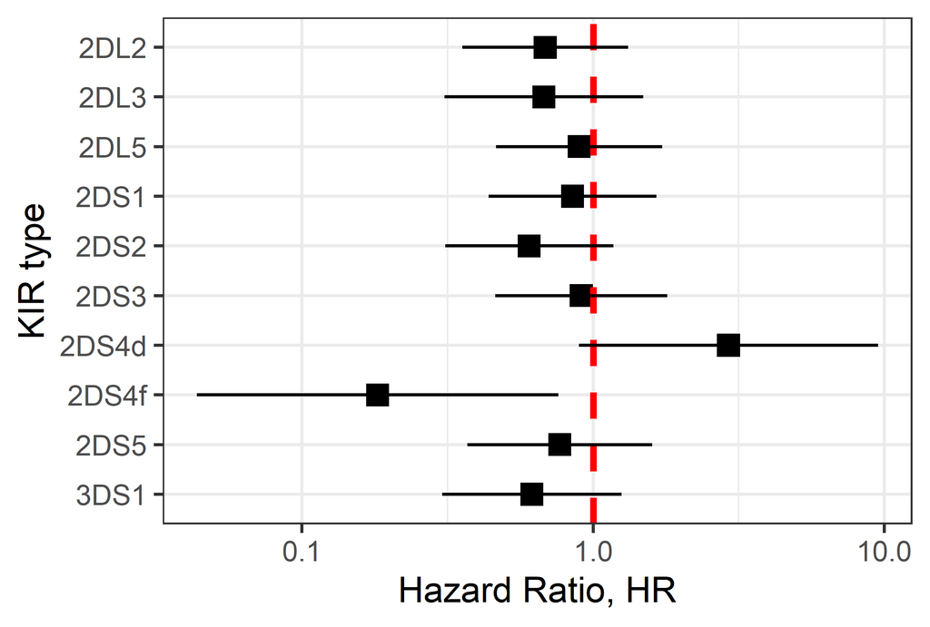

#### HLA

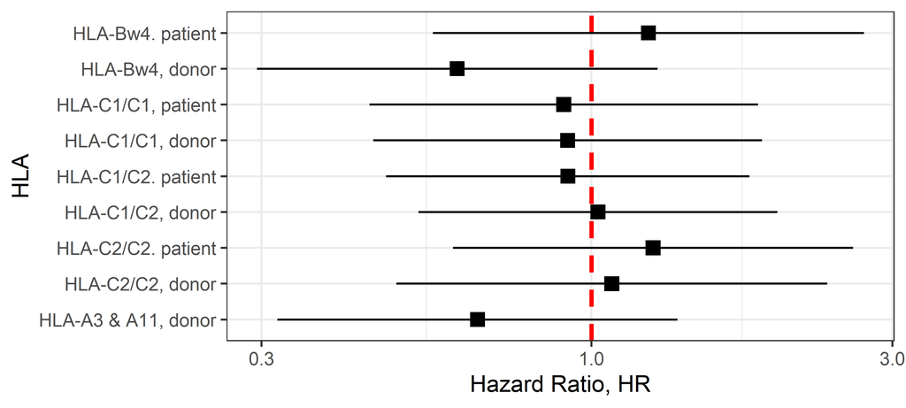

#### Mismatches

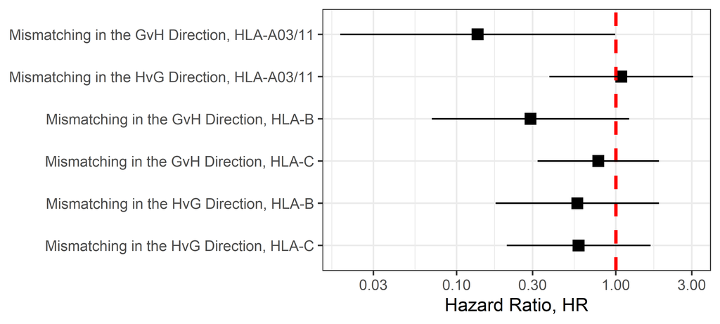

### Кривые выживаемости для разных факторов

#### Возраст

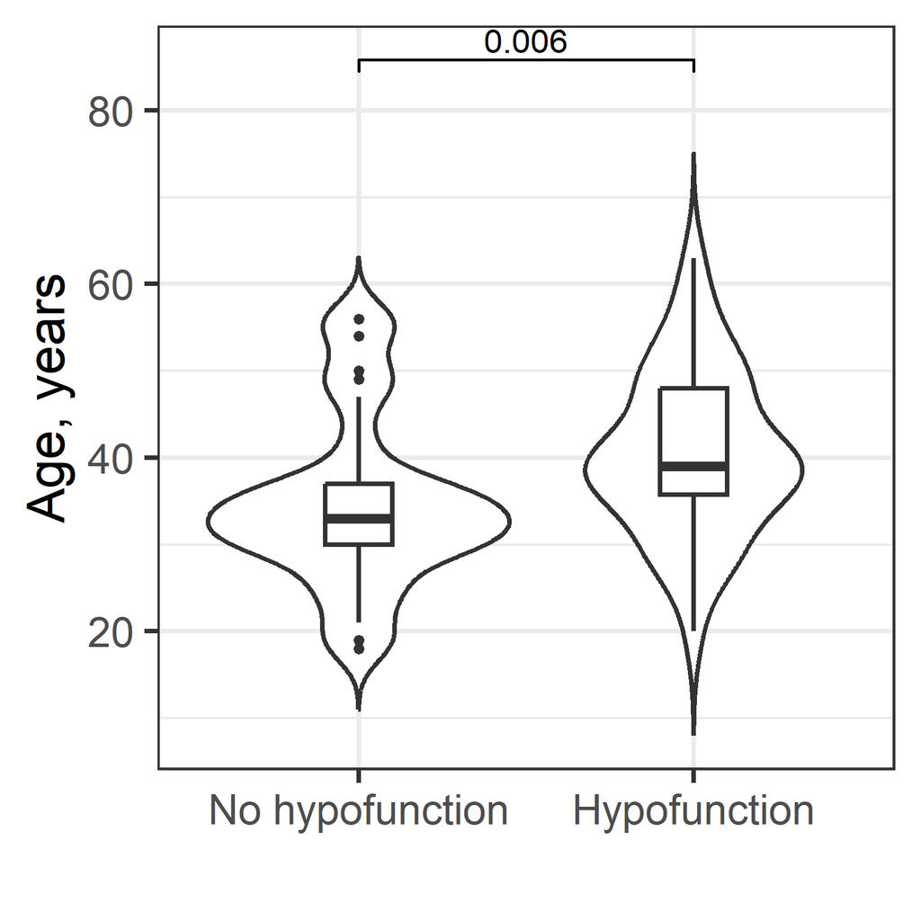

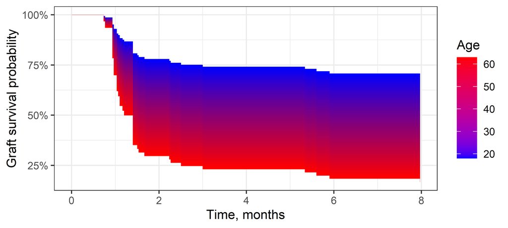

#### Тип трансплантата

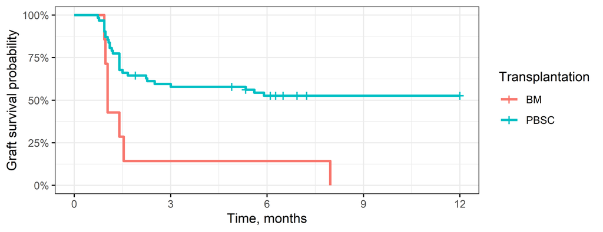

#### Наличие 2DS4f KIR-рецептора

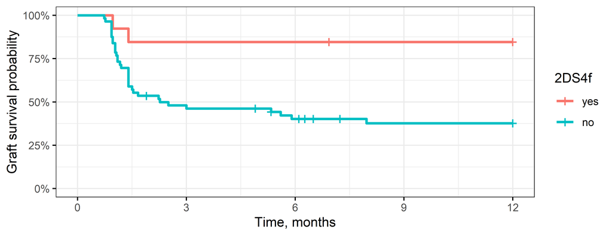

#### Mismatching in the GvH Direction, HLA-A03/11

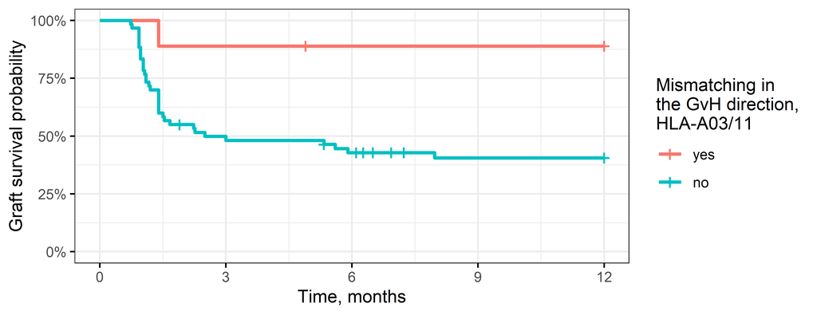

#### Модель, которая учитывает все факторы

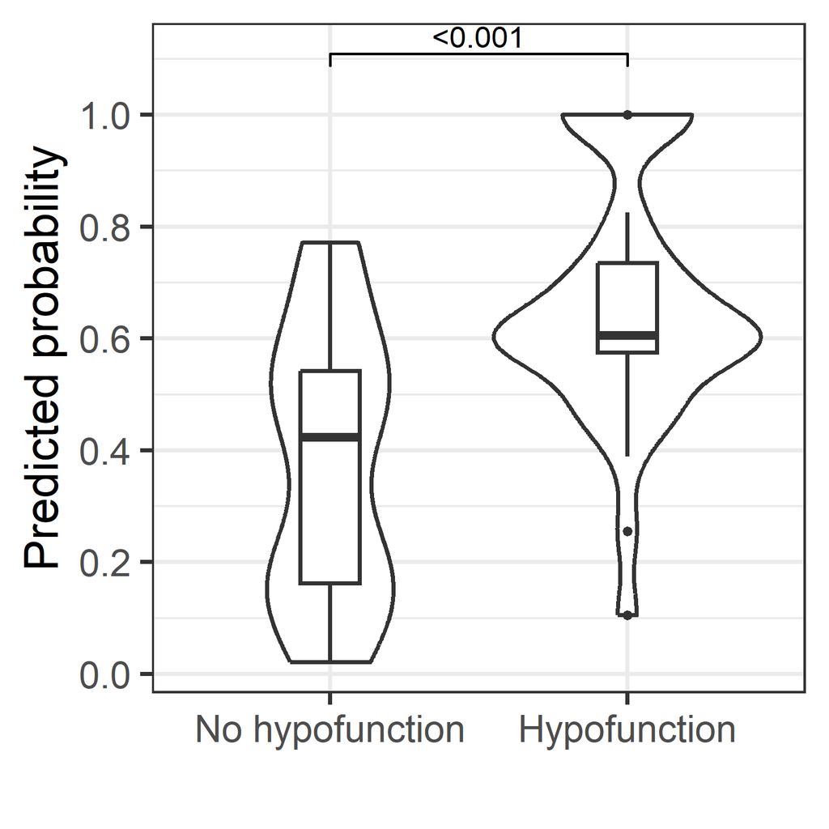

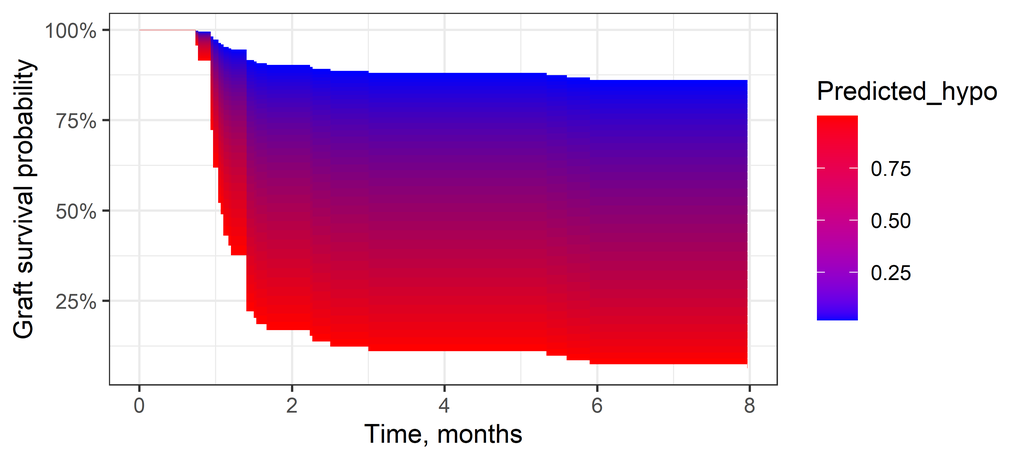

# Анализ общей выживаемости

## Демография + Анамнез

| **Characteristic** | **Death** **0**, N = 39<sup>1</sup> | **Death** **1**, N = 30<sup>1</sup> | **p-value**<sup>2</sup> |  |
| --- | --- | --- | --- | --- |
| Age | 36 (30, 39) | 39 (33, 49) |  | 0.070 |
| Sex |  |  | 0.047 |  |
| female | 25 (64%) | 12 (40%) |  |  |
| male | 14 (36%) | 18 (60%) |  |  |
| Diagnosis |  |  | 0.11 |  |
| ALL | 11 (28%) | 14 (47%) |  |  |
| AML | 28 (72%) | 16 (53%) |  |  |
| BMT number |  |  | 0.3 |  |
| 1 | 38 (97%) | 27 (90%) |  |  |
| 2 | 1 (2.6%) | 1 (3.3%) |  |  |
| 3 | 0 (0%) | 2 (6.7%) |  |  |
| Transplantation |  |  | 0.2 |  |
| BM | 2 (5.1%) | 5 (17%) |  |  |
| PBSC | 37 (95%) | 25 (83%) |  |  |
| Failure |  |  | 0.007 |  |
| Primary | 10 (26%) | 13 (43%) |  |  |
| Secondary | 4 (10%) | 9 (30%) |  |  |
| None | 25 (64%) | 8 (27%) |  |  |

<sup>1</sup> Median (IQR); n (%)  
<sup>2</sup> Wilcoxon rank sum test; Pearson’s Chi-squared test; Fisher’s exact test

## КИРы

| **Characteristic** | **Death** **0**, N = 39<sup>1</sup> | **Death** **1**, N = 30<sup>1</sup> | **p-value**<sup>2</sup> |  |
| --- | --- | --- | --- | --- |
| 2DL1 |  |  |  | >0.9 |
| yes | 38 (56%) | 30 (44%) |  |  |
| no | 1 (100%) | 0 (0%) |  |  |
| 2DL2 |  |  | 0.007 |  |
| yes | 27 (71%) | 11 (29%) |  |  |
| no | 12 (39%) | 19 (61%) |  |  |
| 2DL3 |  |  | 0.4 |  |
| yes | 31 (54%) | 26 (46%) |  |  |
| no | 8 (67%) | 4 (33%) |  |  |
| 2DL5 |  |  | 0.6 |  |
| yes | 21 (54%) | 18 (46%) |  |  |
| no | 18 (60%) | 12 (40%) |  |  |
| 2DS1 |  |  | 0.3 |  |
| yes | 15 (50%) | 15 (50%) |  |  |
| no | 24 (62%) | 15 (38%) |  |  |
| 2DS2 |  |  | 0.009 |  |
| yes | 24 (73%) | 9 (27%) |  |  |
| no | 15 (42%) | 21 (58%) |  |  |
| 2DS3 |  |  | 0.5 |  |
| yes | 16 (62%) | 10 (38%) |  |  |
| no | 23 (53%) | 20 (47%) |  |  |
| 2DS4d |  |  | 0.9 |  |
| yes | 32 (56%) | 25 (44%) |  |  |
| no | 7 (58%) | 5 (42%) |  |  |
| 2DS4f |  |  | 0.10 |  |
| yes | 10 (77%) | 3 (23%) |  |  |
| no | 29 (52%) | 27 (48%) |  |  |
| 2DS5 |  |  | 0.3 |  |
| yes | 10 (48%) | 11 (52%) |  |  |
| no | 29 (60%) | 19 (40%) |  |  |

[output cut: 63 more lines]

<sup>1</sup> n (%); Median (IQR)  
<sup>2</sup> Fisher’s exact test; Pearson’s Chi-squared test; Wilcoxon rank sum test

## Время до наступления события

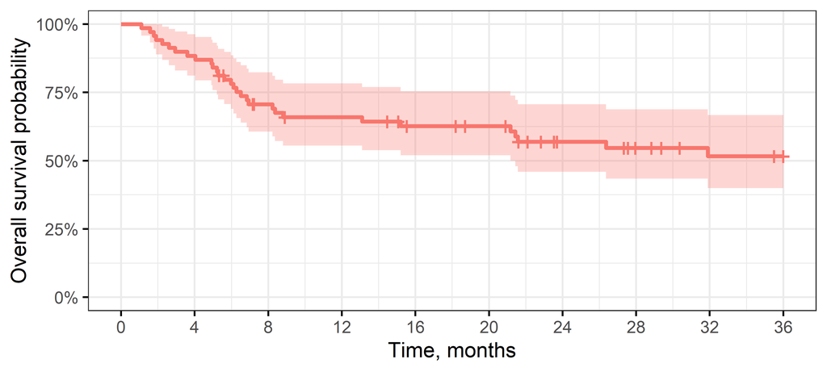

### Однофакторный анализ времени до наступления события

#### Анамнез + демография

| **Characteristic** | **N** | **HR**<sup>1</sup> | **95% CI**<sup>1</sup> | **p-value** |
| --- | --- | --- | --- | --- |
| Age | 69 | 1.03 | 1.00, 1.07 | 0.053 |
| Sex | 69 |  |  |  |
| female |  | — | — |  |
| male |  | 1.73 | 0.84, 3.60 | 0.14 |
| Diagnosis | 69 |  |  |  |
| ALL |  | — | — |  |
| AML |  | 0.58 | 0.28, 1.19 | 0.14 |
| BMT number | 69 | 1.45 | 0.72, 2.91 | 0.3 |
| Transplantation | 69 |  |  |  |
| BM |  | — | — |  |
| PBSC |  | 0.50 | 0.19, 1.30 | 0.2 |

<sup>1</sup> HR = Hazard Ratio, CI = Confidence Interval

#### KIR

| **Characteristic** | **N** | **HR**<sup>1</sup> | **95% CI**<sup>1</sup> | **p-value** |
| --- | --- | --- | --- | --- |
| 2DL1 | 69 | 25,156,660 | 0.00, Inf | >0.9 |
| 2DL2 | 69 | 0.33 | 0.15, 0.69 | 0.003 |
| 2DL3 | 69 | 1.68 | 0.58, 4.82 | 0.3 |
| 2DL5 | 69 | 1.34 | 0.64, 2.77 | 0.4 |
| 2DS1 | 69 | 1.53 | 0.75, 3.14 | 0.2 |
| 2DS2 | 69 | 0.35 | 0.16, 0.76 | 0.008 |
| 2DS3 | 69 | 0.78 | 0.37, 1.67 | 0.5 |
| 2DS4d | 69 | 1.01 | 0.38, 2.63 | >0.9 |
| 2DS4f | 69 | 0.39 | 0.12, 1.28 | 0.12 |
| 2DS5 | 69 | 1.60 | 0.76, 3.37 | 0.2 |
| 3DS1 | 69 | 1.72 | 0.84, 3.54 | 0.14 |
| Best VS Better/Neutral | 69 | 0.58 | 0.20, 1.68 | 0.3 |
| Best/Better VS Neutral | 69 | 0.59 | 0.27, 1.29 | 0.2 |
| Mismatching in the GvH Direction, HLA-A03/11 | 69 | 0.44 | 0.10, 1.85 | 0.3 |
| Mismatching in the HvG Direction, HLA-A03/11 | 69 | 0.56 | 0.13, 2.37 | 0.4 |
| HLA-Bw4. patient | 69 | 1.18 | 0.48, 2.89 | 0.7 |
| HLA-Bw4, donor | 69 | 0.99 | 0.40, 2.42 | >0.9 |
| HLA-C1/C1, patient | 69 | 1.35 | 0.64, 2.84 | 0.4 |
| HLA-C1/C1, donor | 69 | 1.54 | 0.73, 3.24 | 0.3 |
| HLA-C1/С2. patient | 69 | 0.73 | 0.35, 1.55 | 0.4 |
| HLA-C1/С2, donor | 69 | 0.46 | 0.22, 0.99 | 0.046 |
| HLA-C2/C2. patient | 69 | 1.04 | 0.46, 2.34 | >0.9 |
| HLA-C2/C2, donor | 69 | 1.65 | 0.75, 3.60 | 0.2 |
| KIR-genotype A/A vs B/X | 69 | 1.58 | 0.76, 3.30 | 0.2 |
| KIR-genotype B/B vs A/X | 69 | 0.72 | 0.29, 1.76 | 0.5 |
| Mismatching in the GvH Direction, HLA-B | 69 | 0.67 | 0.20, 2.19 | 0.5 |
| Mismatching in the GvH Direction, HLA-C | 69 | 0.48 | 0.17, 1.38 | 0.2 |
| Mismatching in the HvG Direction, HLA-B | 69 | 0.47 | 0.11, 1.97 | 0.3 |
| Mismatching in the HvG Direction, HLA-C | 69 | 1.03 | 0.39, 2.70 | >0.9 |
| HLA-А3 & А11, donor | 69 | 1.39 | 0.67, 2.89 | 0.4 |
| KIR count | 69 | 0.97 | 0.83, 1.13 | 0.7 |
| KIR active | 69 | 0.98 | 0.80, 1.21 | 0.8 |
| KIR ingibited | 69 | 0.88 | 0.57, 1.36 | 0.6 |

<sup>1</sup> HR = Hazard Ratio, CI = Confidence Interval